# NEO-SMART Engine: knowledge base

NSF Regional Innovation Engines, Cohort 2. Technology profile v3.1. Draft, in progress

**NSF NEO-SMART Engine in Northeast Ohio**, led by Case Western Reserve University. NSF award 2532460, start August 2026. Search window for papers and patents: from August 2021 (five years before the award) onward.

## At a glance

| Measure | Value |
| --- | --- |
| People named by NSF or the Engine’s site | 10 |
| of them active researchers (>= 5 works since window start) | 0 |
| Team members who are inventors (2021-2025 grants, in the region) | 0 |
| Partners (site list + team members’ organisations) | 76 |
| Knowledge-producer partners (universities, labs, institutes) | 12 |
| Partner papers in the Engine’s topics | 527 |
| of them with an in-region partner | 193 |
| Regional patents in the technology profile (2021-2025 grants) | 43 |
| Location quotient of the technology profile (patents) | 3.76 |
| Share of regional technology patents owned by partners | 11.6% |

## Economic base

| NAICS | Industry | Employment in region | Establishments | Share of US employment | Employment LQ |
| --- | --- | --- | --- | --- | --- |
| 325 | Chemical manufacturing | 19,151 | 323 | 2.1% | 1.67 |
| 3255 | Paint, coating, and adhesive manufacturing | 3,683 | 49 | 4.7% | 3.76 |
| 326 | Plastics and rubber products manufacturing | 28,083 | 401 | 3.4% | 2.74 |
| 331 | Primary metal manufacturing | 18,643 | 186 | 5.2% | 4.18 |
| 332 | Fabricated metal product manufacturing | 47,221 | 1,610 | 3.3% | 2.61 |

Industries related to the Engine’s technology (chosen from the NSF abstract, see `data/manual/engine_naics.csv`). County Business Patterns 2023; LQ = the industry’s share of regional employment relative to its share of US employment (1 = US average). Region: 18 of 18.

## Technology profile

Version 3.1, core. The NSF abstract names 4 technologies of this Engine (scientific and technical fragments extracted with a fixed prompt; the extraction was done by hand in a chat session, not reproducible). For each technology, all 4,516 OpenAlex topics and all CPC main groups are ranked by several independent signals; the core keeps up to 2 topics and 2 CPC main groups per technology. *Judge*: chosen by a rubric judge where no candidate was confirmed by two kinds of evidence (also by hand in a chat session). An empty cell: no suitable item among the candidates. See Methodology and the comparison of versions.

| # | Technology | OpenAlex topics | CPC main groups |
| --- | --- | --- | --- |
| 1 | metals | T14184 Metallurgy and Material Science (judge) | B22D21/00 Casting non-ferrous metals or metallic compounds so far as their metallurgical properties are of importance for the casting procedure; Selection of compositions therefor (judge) C22B7/00 Wor… |
| 2 | polymers | T14454 Polymer Science and Applications | C08G81/00 Macromolecular compounds obtained by interreacting polymers in the absence of monomers, e.g. block polymers D01F6/00 Monocomponent artificial filaments or the like of synthetic polymers; Man… |
| 3 | chemicals and coatings | T10495 Catalysts for Methane Reforming (judge) T10310 Corrosion Behavior and Inhibition (judge) | C09D149/00 Coating compositions based on homopolymers or copolymers of compounds having one or more carbon-to-carbon triple bonds; Coating compositions based on derivatives of such polymers (judge) C0… |
| 4 | AI/ML materials design and life cycle assessment | T10435 Environmental Impact and Sustainability T12938 Material Selection and Properties | G16C60/00 Computational materials science, i.e. ICT specially adapted for investigating the physical or chemical properties of materials or phenomena associated with their design, synthesis, processin… |

## People

| Role | People |
| --- | --- |
| organizer | 7 |
| research_admin | 2 |
| corporate_rd | 1 |

| Name | Role | On NSF award | Title | Organisation | Works since window (in Engine topics) | h-index | Patents 2021-25 (in Engine profile) | Site | OpenAlex |
| --- | --- | --- | --- | --- | --- | --- | --- | --- | --- |
| Michael Oakes | research_admin |  | Executive Vice President for Research | Case Western Reserve University | - | - |  | [page](https://neosmartengine.org/about/) |  |
| Nigamanth Sridhar | research_admin |  | Executive Vice President & Provost | Cleveland State University | 2 (0) | 13 |  | [page](https://neosmartengine.org/about/) | [profile](https://openalex.org/A5041569881) |
| Julie Edgar | corporate_rd |  | Chief Technology Officer | The Lubrizol Corporation | 0 | 4 |  | [page](https://neosmartengine.org/about/) | [profile](https://openalex.org/A5040514198) |
| Baiju Shah | organizer | Co-PI | President & CEO | Greater Cleveland Partnership | - | - |  | [page](https://neosmartengine.org/about/) |  |
| Bethia Burke | organizer | Co-PI | President | Fund for Our Economic Future | - | - |  | [page](https://neosmartengine.org/about/) |  |
| Catherine Tkachyk | organizer |  | Chief Operating Officer (Interim) | NEO-SMART | - | - |  | [page](https://neosmartengine.org/about/) |  |
| Marcia Ballinger | organizer | Co-PI | President | Lorain County Community College | - | - |  | [page](https://neosmartengine.org/about/) |  |
| Matt Dolan | organizer | Co-PI | CEO | Team NEO | - | - |  | [page](https://neosmartengine.org/about/) |  |
| Nick Barendt | organizer | PI | Chief Executive Officer and Principal Investigator; Gover… | NEO-SMART | 0 | 6 |  | [page](https://neosmartengine.org/about/) | [profile](https://openalex.org/A5007924702) |
| Steve Millard | organizer |  | President & CEO | Greater Akron Chamber | - | - |  | [page](https://neosmartengine.org/about/) |  |

Publication counts are shown only where the OpenAlex author matches both the name and the person’s current organisation. The OpenAlex link is given only for these reliable matches, and not for profiles flagged as possibly merging several namesakes. *Site* links to the page of the Engine’s website where the person is named. Click a number of works to see the list on the Publications page. *Patents*: US grants 2021-2025 with the person among the inventors (same last and first name, address in the Engine’s states); click the number for the list on the Patents page. In brackets: works in the Engine’s topics, patents with a CPC code in the Engine’s technology profile.

## Researchers at partner organisations

| # | Researcher | Partner | Works in the Engine’s topics | Citations | Years | Most cited of these works |
| --- | --- | --- | --- | --- | --- | --- |
| 1 | [David M. Bastidas](https://openalex.org/A5005429869) | University of Akron | 20 | 267 | 2021-2026 | [Corrosion Inhibition Mechanism of Steel Reinforcements in…](https://openalex.org/W3207729797) |
| 2 | [Chris Yingchun Yuan](https://openalex.org/A5024601679) | Case Western Reserve University | 10 | 316 | 2022-2025 | [Techno-economic and environmental sustainability of indus…](https://openalex.org/W4205478767) |
| 3 | [Ulises Martin](https://openalex.org/A5078114526) | University of Akron | 10 | 175 | 2021-2024 | [Corrosion Inhibition Mechanism of Steel Reinforcements in…](https://openalex.org/W3207729797) |
| 4 | [Mark D. Soucek](https://openalex.org/A5069375863) | University of Akron | 7 | 98 | 2021-2025 | [Investigation of abiotic degradation of tire cryogrinds](https://openalex.org/W4200457374) |
| 5 | [Jomin Thomas](https://openalex.org/A5042904069) | University of Akron | 6 | 230 | 2021-2024 | [The Road to Sustainable Tire Materials: Current State-of-…](https://openalex.org/W4318755308) |
| 6 | [Steven S. C. Chuang](https://openalex.org/A5109958887) | University of Akron | 6 | 120 | 2021-2025 | [Electrocatalytic Methane Oxidation to Ethanol on Iron-Nic…](https://openalex.org/W4283217291) |
| 7 | [Qixin Zhou](https://openalex.org/A5053711093) | University of Akron | 6 | 87 | 2021-2025 | [AC corrosion of steel pipeline under cathodic protection:…](https://openalex.org/W4387055084) |
| 8 | [Sanjay Rajagopalan](https://openalex.org/A5022334933) | Case Western Reserve University | 6 | 50 | 2022-2026 | [Environmental sustainability in cardiovascular practice: …](https://openalex.org/W4403766672) |
| 9 | [Kang Shen](https://openalex.org/A5031878694) | Case Western Reserve University | 5 | 158 | 2022-2024 | [Cradle-to-gate life cycle assessment of all-solid-state l…](https://openalex.org/W4206975601) |
| 10 | [Jacob Ress](https://openalex.org/A5029108082) | University of Akron | 5 | 88 | 2021-2022 | [Corrosion Inhibition Mechanism of Steel Reinforcements in…](https://openalex.org/W3207729797) |
| 11 | [John M. Senko](https://openalex.org/A5040287366) | University of Akron | 5 | 13 | 2022-2024 | [Electrochemical Detection of Carbon Steel Corrosion Induc…](https://openalex.org/W4405223486) |
| 12 | [Sai Prasanna Chinthala](https://openalex.org/A5055596158) | Cleveland State University | 5 | 13 | 2022-2024 | [Electrochemical Detection of Carbon Steel Corrosion Induc…](https://openalex.org/W4405223486) |
| 13 | [Ahmed Yousef Mohamed](https://openalex.org/A5085619961) | University of Akron | 4 | 97 | 2022-2023 | [Adsorption and Surface Analysis of Sodium Phosphate Corro…](https://openalex.org/W4307262314) |
| 14 | [Lizeth Sánchez](https://openalex.org/A5015796154) | University of Akron | 4 | 64 | 2021-2022 | [AC induced pitting and pit-to-crack transition of low car…](https://openalex.org/W4225161316) |
| 15 | [Donald P. Visco](https://openalex.org/A5020668440) | University of Akron | 4 | 59 | 2022-2026 | [Effect of cations on the activity coefficient of NO2–/NO3…](https://openalex.org/W4284964092) |

The grant names mostly managers; the technology is often developed at the partner universities and labs. These are the authors with the most works in the Engine’s OpenAlex topics written at a knowledge-producer partner in the Engine’s states, since the window start (at least 3 works; top 15). The list depends on the technology profile version. OpenAlex sometimes merges namesakes into one author: check the profile before relying on a name.

## Partners

| Organisation class | Partners |
| --- | --- |
| company | 29 |
| intermediary | 21 |
| government | 6 |
| university | 6 |
| community_college | 4 |
| research_institute | 4 |
| investor | 2 |
| national_lab | 2 |
| philanthropy | 2 |

Partner list on the site: *Complete (74 organisations)*.

| Partner | Class | State | OpenAlex works since window (all topics) |
| --- | --- | --- | --- |
| Case Western Reserve University | university | Ohio | 41410 |
| Argonne National Laboratory | national_lab | Illinois | 28153 |
| Kent State University | university |  | 8881 |
| RTI International | research_institute | North Carolina | 5846 |
| University of Akron | university | Ohio | 4049 |
| Cleveland State University | university | Ohio | 4006 |
| NASA Glenn Research Center | national_lab | Ohio | 1974 |
| Youngstown State University | university | Ohio | 1048 |
| Walsh University | university | Ohio | 123 |
| ReMADE Institute | research_institute | New York | 4 |
| NSF HAMMER-ERC | research_institute |  | NA |
| NSF TARDISS-ERC | research_institute |  | NA |

## Science base: partner papers in the Engine’s topics

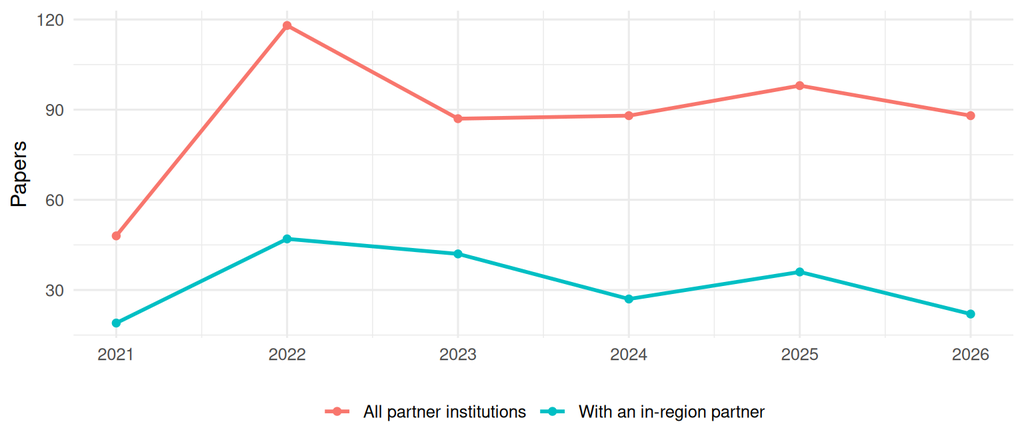

| Partner | Papers in topics |
| --- | --- |
| Argonne National Laboratory | 327 |
| University of Akron | 95 |
| Case Western Reserve University | 67 |
| Cleveland State University | 21 |
| NASA Glenn Research Center | 8 |
| RTI International | 6 |
| Kent State University | 5 |
| Walsh University | 5 |
| Youngstown State University | 3 |

## Technology base: patents

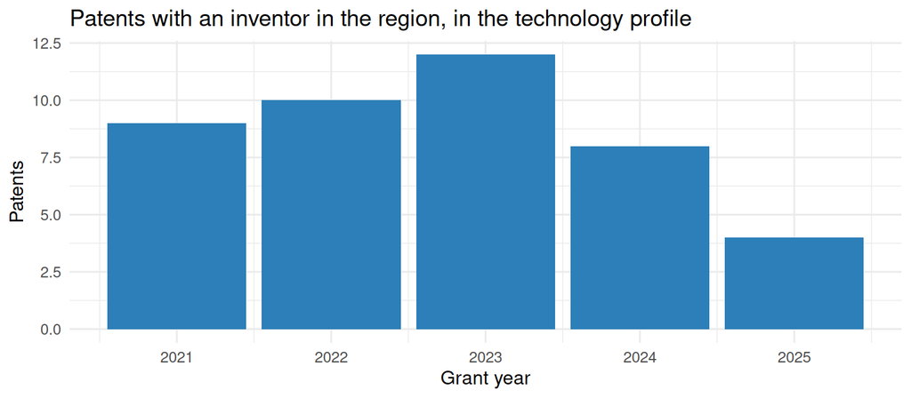

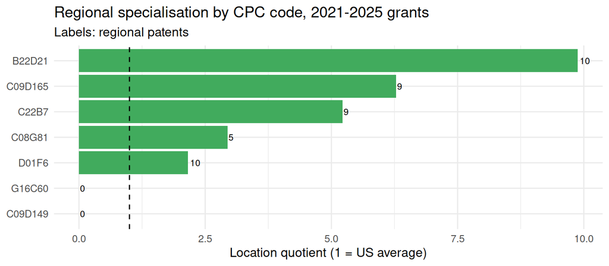

| Assignee | Regional patents in profile |
| --- | --- |
| PROMERUS, LLC | 7 |
| Terves, LLC | 5 |
| Lubrizol Advanced Materials, Inc. | 4 |
| CHZ TECHNOLOGIES, LLC | 3 |
| Molten Metal Equipment Innovations, LLC | 3 |
| THE UNIVERSITY OF AKRON | 2 |
| BASF SE | 1 |
| BRIDGESTONE CORPORATION | 1 |
| CORNELL UNIVERSITY | 1 |
| Case Western Reserve University | 1 |

Partner-owned patents invented in the region: 1728, of which 5 (0.3%) fall in the Engine’s technology profile.

## Competition

With 43 patents in the technology profile (2021-2025 grants), the Engine’s region would rank **10** among US states; its specialisation (LQ) is 3.761.

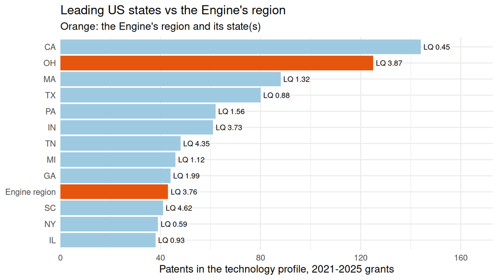

| Country | Share of US patents in profile | Share of world papers in topics |
| --- | --- | --- |
| US | 41.0% | 6.2% |
| JP | 17.5% | 2.4% |
| CN | 12.5% | 25.1% |
| KR | 8.2% | 1.9% |
| DE | 6.2% | 3.0% |
| TW | 3.5% | NA |
| FR | 2.5% | 2.4% |
| GB | 2.3% | 3.2% |
| BE | 2.2% | NA |
| CA | 2.2% | NA |

Patents: inventor countries on US grants in the profile (a patent counts for every country of its inventors). Papers: author countries of OpenAlex works in the Engine’s topics since the window start.

## Data and limitations

- People: PIs and Co-PIs from the NSF Award API; leadership listed on the Engine’s website. Roles come from titles and organisations, revised with OpenAlex evidence.
- Partners: as listed on the Engine’s website, plus organisations of team members. Some Engines publish partner logos without names.
- Region: the Engine’s counties where the list is known (NEO-SMART: 18 Northeast Ohio counties; STELLAR: 11 counties from the NSF abstract), otherwise its states (state-level proxy).
- Technology profile: v3.1 (switch versions in the header). Partner papers and regional patents depend on it: v1 uses mostly CPC subclasses, the v3.1 core uses CPC main groups, which are narrower, so it counts fewer patents and the LQ of a small region rests on few patents.
- Papers: OpenAlex; partner papers are restricted to the Engine’s OpenAlex topics.
- Patents: USPTO grants 2021-2025; inventor locations from PatentsView; pre-grant publications are not included.